# Project Foundations for Data Science: FoodHub Data Analysis

### Analyze the total time required to deliver the food. Percentage of orders that take more than 60 minutes to get delivered from the time the order is placed.

```python
# first let's calculate the total time from the order to the delivery
df['total_time'] = df['food_preparation_time'] + df['delivery_time']

#now let's see the percentage of orders that will take more than 60 mins
over_60 = df[df['total_time'] > 60] #find the total number
over_percentage = (len(over_60) / len(df)) * 100 #use previous step to determine the percentage

print(f"The percentage of orders longer than 60 minutes is {over_percentage:.2f}%")
```

```
The percentage of orders longer than 60 minutes is 10.54%
```

#### Observations:

We can see that only 10.54 percent of the orders take longer than 60 minutes which is a low number. However, it would be optimal to minimize this number as much as we can so we do not have to keep our customers waiting at all. Creating a function to solve this can also help with efficiency and makes the code look better.

### Analyze the delivery time of the orders on weekdays and weekends.

```python
# Let's compare the mean delivery times between the two day of the week categories(weekday & weekend)

avg_time = df.groupby('day_of_the_week')['delivery_time'].mean()
print(avg_time)
```

```
day_of_the_week
Weekday    28.340037
Weekend    22.470022
Name: delivery_time, dtype: float64
```

#### Observations:

Looking at the results, we can see that weekends have an average of a shorter delivery time than weekdays. Similar to a previous question, we were able to see that weekends have shorter times as the box plot was located lower on the y-axis, which represented the delivery time. This would be a result of more availability of delivery drivers or a more flexible schedule of the drivers over the weekends.

# Customer Segmentation Using K-Means Clustering

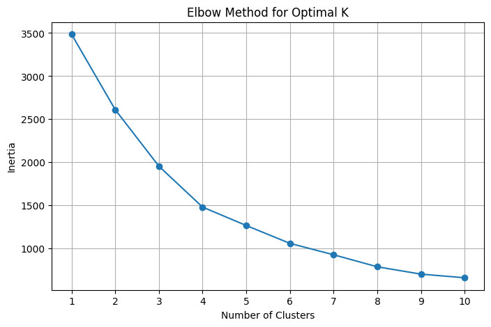

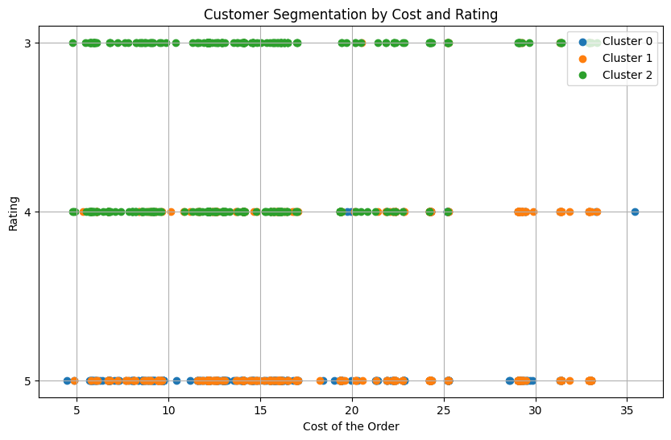

```python
# Step 1: Selecting features for clustering
features = df[['cost_of_the_order', 'rating', 'delivery_time']]

# Step 2: Handling non-numeric values
# Replace 'Not given' or other non-numeric values with NaN
features = features.replace('Not given', pd.NA)

# Drop rows with missing or non-numeric values
features_cleaned = features.dropna()

# Synchronize df with cleaned features
df_cleaned = df.loc[features_cleaned.index]

# Ensure all values are numeric
features_cleaned = features_cleaned.astype(float)

# Step 3: Scaling the features
from sklearn.preprocessing import StandardScaler
scaler = StandardScaler()
scaled_features_cleaned = scaler.fit_transform(features_cleaned)

# Step 4: Determine the optimal number of clusters using the Elbow method
from sklearn.cluster import KMeans
import matplotlib.pyplot as plt

inertia = []  # List to store inertia values
for k in range(1, 11):  # Test cluster sizes from 1 to 10
    kmeans = KMeans(n_clusters=k, random_state=42)
    kmeans.fit(scaled_features_cleaned)
    inertia.append(kmeans.inertia_)

# Plotting the Elbow Curve
plt.figure(figsize=(8, 5))
plt.plot(range(1, 11), inertia, marker='o')
plt.title('Elbow Method for Optimal K')
plt.xlabel('Number of Clusters')
plt.ylabel('Inertia')
plt.xticks(range(1, 11))
plt.grid(True)
plt.show()

# Step 5: Apply K-Means clustering with optimal number of clusters (e.g., k=3)
optimal_k = 3  # Choose the appropriate value based on the elbow curve
kmeans = KMeans(n_clusters=optimal_k, random_state=42)
df_cleaned['Cluster'] = kmeans.fit_predict(scaled_features_cleaned)

# Step 6: Visualizing clusters
plt.figure(figsize=(10, 6))
for cluster in range(optimal_k):
    cluster_data = df_cleaned[df_cleaned['Cluster'] == cluster]
    plt.scatter(
        cluster_data['cost_of_the_order'],
        cluster_data['rating'],
        label=f'Cluster {cluster}'
    )
plt.title('Customer Segmentation by Cost and Rating')
plt.xlabel('Cost of the Order')
plt.ylabel('Rating')
plt.legend()
plt.grid(True)
plt.show()
```

# Predicting Customer Conversion Using Classification Models

This section builds a machine learning model to predict customer satisfaction using features like cost of the order, delivery time, and total time. The data is cleaned and prepared by handling missing values and creating a target variable based on customer ratings. A Random Forest Classifier is trained with hyperparameter tuning and cross-validation, and the model's performance is evaluated using metrics like confusion matrix, classification report, and ROC curve. Feature importance is also analyzed to understand which factors influence predictions.

```
Best Model Parameters: {'bootstrap': True, 'ccp_alpha': 0.0, 'class_weight': None, 'criterion': 'gini', 'max_depth': 10, 'max_features': 'sqrt', 'max_leaf_nodes': None, 'max_samples': None, 'min_impurity_decrease': 0.0, 'min_samples_leaf': 2, 'min_samples_split': 5, 'min_weight_fraction_leaf': 0.0, …

Cross-validation Scores: [0.84662577 0.82822086 0.83435583 0.84567901 0.84567901]
Average CV Score: 0.84 (+/- 0.01)

Classification Report:
               precision    recall  f1-score   support

           0       0.00      0.00      0.00        61
           1       0.83      1.00      0.90       288

    accuracy                           0.83       349
   macro avg       0.41      0.50      0.45       349
weighted avg       0.68      0.83      0.75       349
```

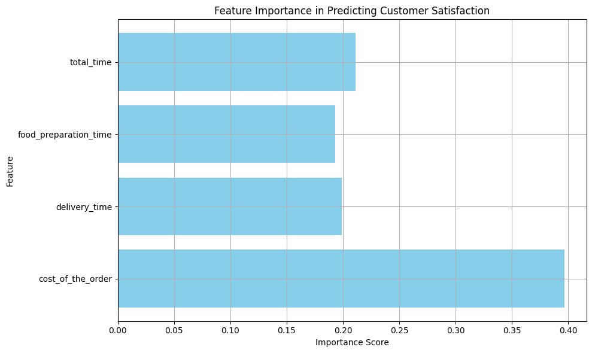

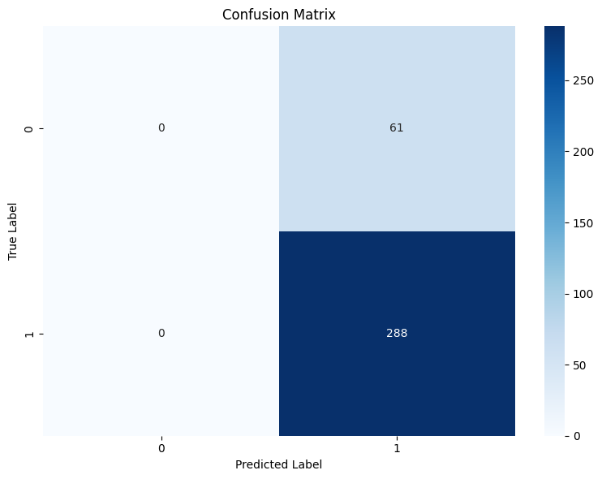

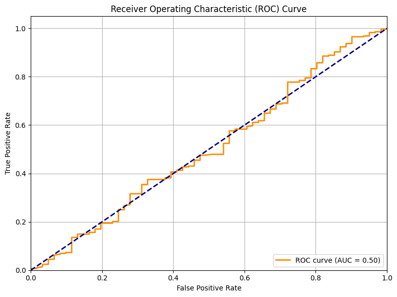

```python
from sklearn.model_selection import train_test_split, cross_val_score, GridSearchCV
from sklearn.ensemble import RandomForestClassifier
from sklearn.metrics import classification_report, confusion_matrix, roc_curve, auc
from sklearn.preprocessing import StandardScaler


def prepare_data(df):
    """
    Prepare the dataset for modeling with proper error handling
    """
    # Step 1: Convert 'rating' to numeric and handle non-numeric values
    df['rating'] = pd.to_numeric(df['rating'], errors='coerce')

    # Step 2: Drop rows with missing or invalid ratings
    df = df.dropna(subset=['rating'])

    # Step 3: Create binary target variable based on 'rating'
    df['satisfied'] = df['rating'].apply(lambda x: 1 if x > 3 else 0)

    return df

def train_evaluate_model(X, y):
    """
    Train and evaluate the model with cross-validation and hyperparameter tuning
    """
    # Split data
    X_train, X_test, y_train, y_test = train_test_split(X, y, test_size=0.3, random_state=42)

    # Scale features
    scaler = StandardScaler()
    X_train_scaled = scaler.fit_transform(X_train)
    X_test_scaled = scaler.transform(X_test)

    # Define hyperparameters to tune
    param_grid = {
        'n_estimators': [100, 200],
        'max_depth': [10, 20, None],
        'min_samples_split': [2, 5],
        'min_samples_leaf': [1, 2]
    }

    # Initialize and tune model
    model = RandomForestClassifier(random_state=42)
    grid_search = GridSearchCV(model, param_grid, cv=5, scoring='f1', n_jobs=-1)
    grid_search.fit(X_train_scaled, y_train)

    # Get best model
    best_model = grid_search.best_estimator_

    # Cross-validation scores
    cv_scores = cross_val_score(best_model, X_train_scaled, y_train, cv=5)

    # Predictions
    y_pred = best_model.predict(X_test_scaled)
    y_pred_proba = best_model.predict_proba(X_test_scaled)[:, 1]

    return best_model, X_train_scaled, X_test_scaled, y_test, y_pred, y_pred_proba, cv_scores

def plot_results(model, X, y_test, y_pred, y_pred_proba):
    """
    Create visualizations for model performance
    """
    # Feature importance plot
    plt.figure(figsize=(10, 6))
    feature_importances = model.feature_importances_
    plt.barh(X.columns, feature_importances, color='skyblue')
    plt.title('Feature Importance in Predicting Customer Satisfaction')
    plt.xlabel('Importance Score')
    plt.ylabel('Feature')
    plt.grid(True)
    plt.tight_layout()
    plt.show()

    # Confusion matrix heatmap
    plt.figure(figsize=(8, 6))
    cm = confusion_matrix(y_test, y_pred)
    sns.heatmap(cm, annot=True, fmt='d', cmap='Blues')
    plt.title('Confusion Matrix')
    plt.ylabel('True Label')
    plt.xlabel('Predicted Label')
    plt.tight_layout()
    plt.show()

    # ROC curve
    fpr, tpr, _ = roc_curve(y_test, y_pred_proba)
    roc_auc = auc(fpr, tpr)
    plt.figure(figsize=(8, 6))
    plt.plot(fpr, tpr, color='darkorange', lw=2, label=f'ROC curve (AUC = {roc_auc:.2f})')
    plt.plot([0, 1], [0, 1], color='navy', lw=2, linestyle='--')
    plt.xlim([0.0, 1.0])
    plt.ylim([0.0, 1.05])
    plt.xlabel('False Positive Rate')
    plt.ylabel('True Positive Rate')
    plt.title('Receiver Operating Characteristic (ROC) Curve')
    plt.legend(loc="lower right")
    plt.grid(True)
    plt.tight_layout()
    plt.show()

# Main execution
try:
    # Prepare data
    df = prepare_data(df)

    # Select features and target
    X = df[['cost_of_the_order', 'delivery_time', 'food_preparation_time', 'total_time']]
    y = df['satisfied']

    # Train and evaluate model
    model, X_train_scaled, X_test_scaled, y_test, y_pred, y_pred_proba, cv_scores = train_evaluate_model(X, y)

    # Print results
    print("\nBest Model Parameters:", model.get_params())
    print("\nCross-validation Scores:", cv_scores)
    print("Average CV Score: {:.2f} (+/- {:.2f})".format(cv_scores.mean(), cv_scores.std() * 2))
    print("\nClassification Report:\n", classification_report(y_test, y_pred))

    # Plot results
    plot_results(model, X, y_test, y_pred, y_pred_proba)

except Exception as e:
    print(f"An error occurred: {str(e)}")
```